# Lung Cancer Risk Analysis

Winn Wu

2025-11-06

### Introduction

This dataset is from Kaggle, designed for lung cancer risk analysis. It contains 50,000 clean, processed profiles from patients who constantly smoke cigarettes, with features based on established lung cancer risk factors such as smoking exposure, environmental exposures, and chronic lung conditions. All data is synthetic and designed to reflect realistic risk factor distributions while maintaining patient privacy.

#### Key Variables

- `age`: Age of the patient (years)
- `gender`: Gender of the patient (Male, Female)
- `pack_years`: Smoking exposure (years * packs/day)
- `radon_exposure`: Exposure to radon (Low, Medium, High)
- `asbestos_exposure`: Exposure to asbestos (No, Yes)
- `secondhand_smoke_exposure`: Exposure to secondhand smoke (No, Yes)
- `copd_diagnosis`: Diagnosis of chronic obstructive pulmonary disease (No, Yes)
- `alcohol_consumption`: Alcohol consumption (None, Moderate, Heavy)
- `family_history`: Family history of lung cancer (No, Yes)
- `lung_cancer`: Diagnosis of lung cancer (No, Yes)

### Data Analysis Objectives

In this project, we will analyze the data to present some basic descriptive statistics and answer the following question:

For the population represented by this dataset, what is the effect of smoking exposure on the risk of developing lung cancer?

### Descriptive Statistics

The following table summarizes the characteristics of all variables in the dataset:

| **Variable** | **Overall, N = 50000** **N = 50,000**<sup>1</sup> |
| --- | --- |
| age | 59 (38, 80) |
| gender |  |
| Female | 25,085 (50%) |
| Male | 24,915 (50%) |
| pack_years | 50 (25, 75) |
| radon_exposure |  |
| High | 16,639 (33%) |
| Low | 16,682 (33%) |
| Medium | 16,679 (33%) |
| asbestos_exposure |  |
| No | 25,151 (50%) |
| Yes | 24,849 (50%) |
| secondhand_smoke_exposure |  |
| No | 24,933 (50%) |
| Yes | 25,067 (50%) |
| copd_diagnosis |  |
| No | 24,934 (50%) |
| Yes | 25,066 (50%) |
| alcohol_consumption |  |
| Heavy | 16,762 (34%) |
| Moderate | 16,576 (33%) |
| None | 16,662 (33%) |
| family_history |  |
| No | 25,017 (50%) |
| Yes | 24,983 (50%) |
| lung_cancer |  |
| No | 15,636 (31%) |
| Yes | 34,364 (69%) |

<sup>1</sup> Median (Q1, Q3); n (%)

This table provides a comprehensive overview of the dataset, showing the distribution of each variable across all patients. For continuous variables, the table shows the median and interquartile range, and shows the number of observations and percentage for categorical variables in each level.

It is useful for understanding the baseline characteristics of the population and for identifying any potential patterns or differences in the data.

### Data Analysis

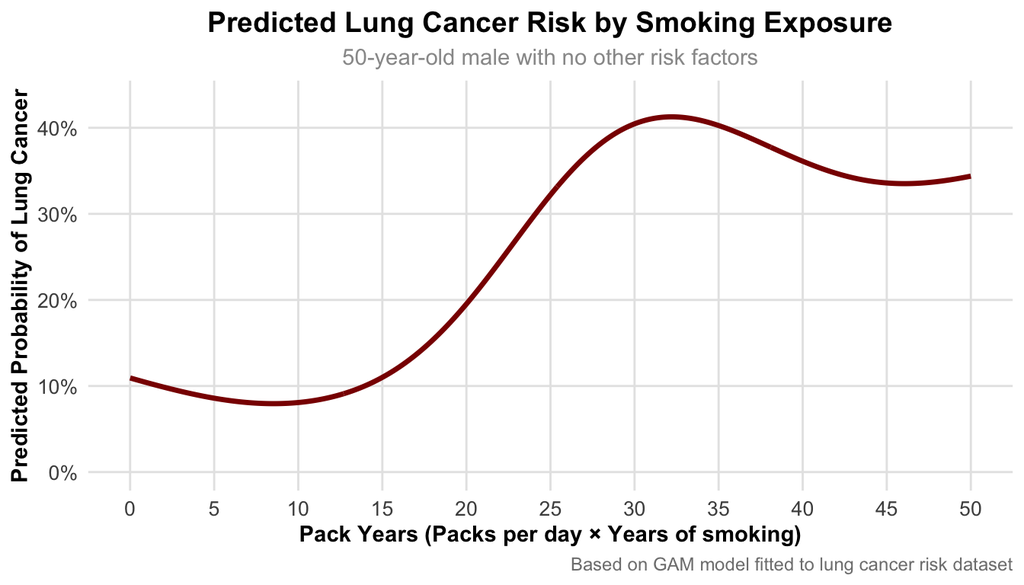